# EDA_sample_Rmd

EDA_sample_Rmd 티타임 2023-12-16

## 0. 패키지 불러오기기

```r
library(tidyverse)
library(GGally)
```

```r
library(corrplot)
library(reshape)
```

## 1. 데이터 불러오기

```r
breast_cancer_data <- read.csv(".//data//breast_cancer.csv")

# 변수 이름
colnames(breast_cancer_data)
```

```
##  [1] "id"                      "diagnosis"
##  [3] "radius_mean"             "texture_mean"
##  [5] "perimeter_mean"          "area_mean"
##  [7] "smoothness_mean"         "compactness_mean"
##  [9] "concavity_mean"          "concave.points_mean"
## [11] "symmetry_mean"           "fractal_dimension_mean"
## [13] "radius_se"               "texture_se"
## [15] "perimeter_se"            "area_se"
## [17] "smoothness_se"           "compactness_se"
## [19] "concavity_se"            "concave.points_se"
## [21] "symmetry_se"             "fractal_dimension_se"
## [23] "radius_worst"            "texture_worst"
## [25] "perimeter_worst"         "area_worst"
## [27] "smoothness_worst"        "compactness_worst"
## [29] "concavity_worst"         "concave.points_worst"
## [31] "symmetry_worst"          "fractal_dimension_worst"
## [33] "X"
```

```r
# 변수의 수
ncol(breast_cancer_data)
```

```
## [1] 33
```

```r
# 전체 데이터의 개수
nrow(breast_cancer_data)
```

```
## [1] 569
```

```r
# 양성 데이터의 개수
nrow(breast_cancer_data %>% filter(diagnosis == "B"))
```

```
## [1] 357
```

```r
# 악성 데이터의 개수
nrow(breast_cancer_data %>% filter(diagnosis == "M"))
```

```
## [1] 212
```

- **Breast_Cancer 데이터**(UCL MACHINE LEARNING)
  - **변수**(총 33가지)
    - **id**(1)
    - **diagnosis**(2): Benign(양성=B), Malignant(악성=M)
    - **radius_mean, se, worst**(3, 13, 23): 중심에서 둘레까지의 거리의 평균, 표준오차, 최대값
    - **texture_mean, se, worst**(4, 14, 24): gray-scale 값의 표준편차의 평균, 표준오차, 최대값
    - **perimeter_mean, se, worst**(5, 15, 25): 핵 종양의 크기의 평균, 표준오차, 최대값
    - **area_mean, se, worst**(6, 16, 26): 핵 종양의 면적의 평균, 표준오차, 최대값
    - **smoothness_mean, se, worst**(7, 17, 27): 반지름 길이의 지역 변동의 평균, 표준오차, 최대값
    - **compactness_mean, se, worst**(8, 18, 28): $radius^2/area-1.0$의 평균, 표준오차, 최대값
    - **concavity_mean, se, worst**(9, 19, 29): 등고선의 오목한 부분의 심각도 평균, 표준오차, 최대값
    - **concave.points_mean, se, worst**(10, 20, 30): 등고선의 오목한 부분의 수의 평균, 표준오차, 최대값
    - **symmetry_mean, se, worst**(11, 21, 31): 대칭성의 평균, 표준오차, 최대값
    - **fractal_dimension_mean, se, worst**(12, 22, 32): $coastline approximation^{-1}$(해안선 근사치의 역수)의 평균, 표준오차, 최대값
    - **X**(33): 미 기재 변수
  - **변수**: 569개
    - **Benign**(양성)의 수: 357개
    - **Malignant**(악성)의 수: 212개

```r
# 결측치 확인.
colSums(is.na(breast_cancer_data))
```

```
##                      id               diagnosis             radius_mean
##                       0                       0                       0
##            texture_mean          perimeter_mean               area_mean
##                       0                       0                       0
##         smoothness_mean        compactness_mean          concavity_mean
##                       0                       0                       0
##     concave.points_mean           symmetry_mean  fractal_dimension_mean
##                       0                       0                       0
##               radius_se              texture_se            perimeter_se
##                       0                       0                       0
##                 area_se           smoothness_se          compactness_se
##                       0                       0                       0
##            concavity_se       concave.points_se             symmetry_se
##                       0                       0                       0
##    fractal_dimension_se            radius_worst           texture_worst
##                       0                       0                       0
##         perimeter_worst              area_worst        smoothness_worst
##                       0                       0                       0
##       compactness_worst         concavity_worst    concave.points_worst
##                       0                       0                       0
##          symmetry_worst fractal_dimension_worst                       X
##                       0                       0                     569
```

X라는 변수열은 전체가 NA로 이루어져 있는데, 분석에 사용하지 않을 id와 함께 X 변수열을 제거해주고, Diagnosis 변수가 현재 character형 데이터이므로 factor로 만들어주겠습니다.

```r
# id, X 변수열 제거
breast_cancer_data = subset(breast_cancer_data, select=c(-1, -33)) #

# diagnosis factor변환
breast_cancer_data$diagnosis= as.factor(breast_cancer_data$diagnosis)

# 확인
str(breast_cancer_data)
```

```
## 'data.frame':    569 obs. of  31 variables:
##  $ diagnosis              : Factor w/ 2 levels "B","M": 2 2 2 2 2 2 2 2 2 2 ...
##  $ radius_mean            : num  18 20.6 19.7 11.4 20.3 ...
##  $ texture_mean           : num  10.4 17.8 21.2 20.4 14.3 ...
##  $ perimeter_mean         : num  122.8 132.9 130 77.6 135.1 ...
##  $ area_mean              : num  1001 1326 1203 386 1297 ...
##  $ smoothness_mean        : num  0.1184 0.0847 0.1096 0.1425 0.1003 ...
##  $ compactness_mean       : num  0.2776 0.0786 0.1599 0.2839 0.1328 ...
##  $ concavity_mean         : num  0.3001 0.0869 0.1974 0.2414 0.198 ...
##  $ concave.points_mean    : num  0.1471 0.0702 0.1279 0.1052 0.1043 ...
##  $ symmetry_mean          : num  0.242 0.181 0.207 0.26 0.181 ...
##  $ fractal_dimension_mean : num  0.0787 0.0567 0.06 0.0974 0.0588 ...
##  $ radius_se              : num  1.095 0.543 0.746 0.496 0.757 ...
##  $ texture_se             : num  0.905 0.734 0.787 1.156 0.781 ...
##  $ perimeter_se           : num  8.59 3.4 4.58 3.44 5.44 ...
```

[output cut: 17 more lines]

## 2. 분포에 대한 시각화.

### 2-1. 진단결과에 따른 Mean 변수들의 분포

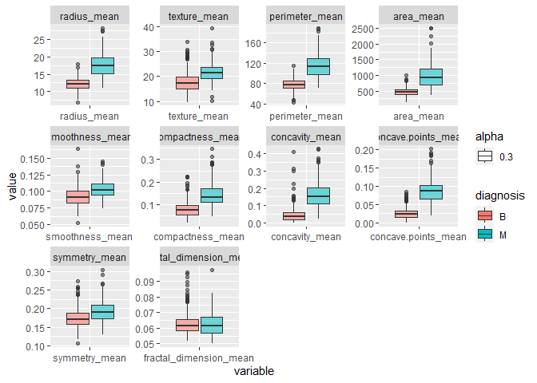

```r
breast_melt3 = melt(breast_cancer_data[,c(1:11)], id.vars = "diagnosis")
ggplot(breast_melt3, aes(x=variable, y=value)) +
  geom_boxplot(aes(alpha=0.3,fill=diagnosis)) +
  facet_wrap(~variable,scale="free")
```

### 2-2. 진단결과에 따른 SE의 분포

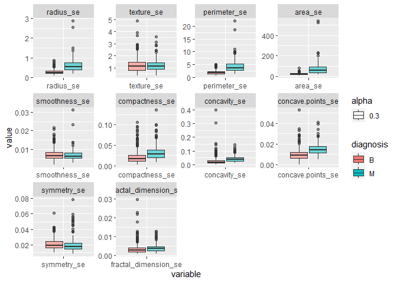

```r
breast_melt2 = melt(breast_cancer_data[,c(1,12:21)], id.vars = "diagnosis")
ggplot(breast_melt2, aes(x=variable, y=value)) +
  geom_boxplot(aes(alpha=0.3,fill=diagnosis)) +
  facet_wrap(~variable,scale="free")
```

### 2-3. 진단결과에 따른 Worst의 분포

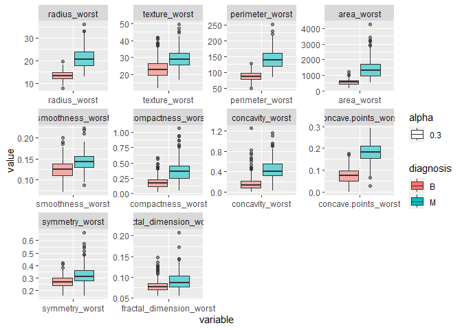

```r
breast_melt3 = melt(breast_cancer_data[,c(1,22:31)], id.vars = "diagnosis")
ggplot(breast_melt3, aes(x=variable, y=value)) +
  geom_boxplot(aes(alpha=0.3,fill=diagnosis)) +
  facet_wrap(~variable,scale="free")
```

## 3. 변수간의 상관성 확인하기.

변수 간의 상관성을 확인해보기 위해서 일단 그룹을 평균, 표준오차, Worst 변수로 나눠서 상관성을 확인하겠습니다.

### 3-1. 평균 변수에서의 상관성.

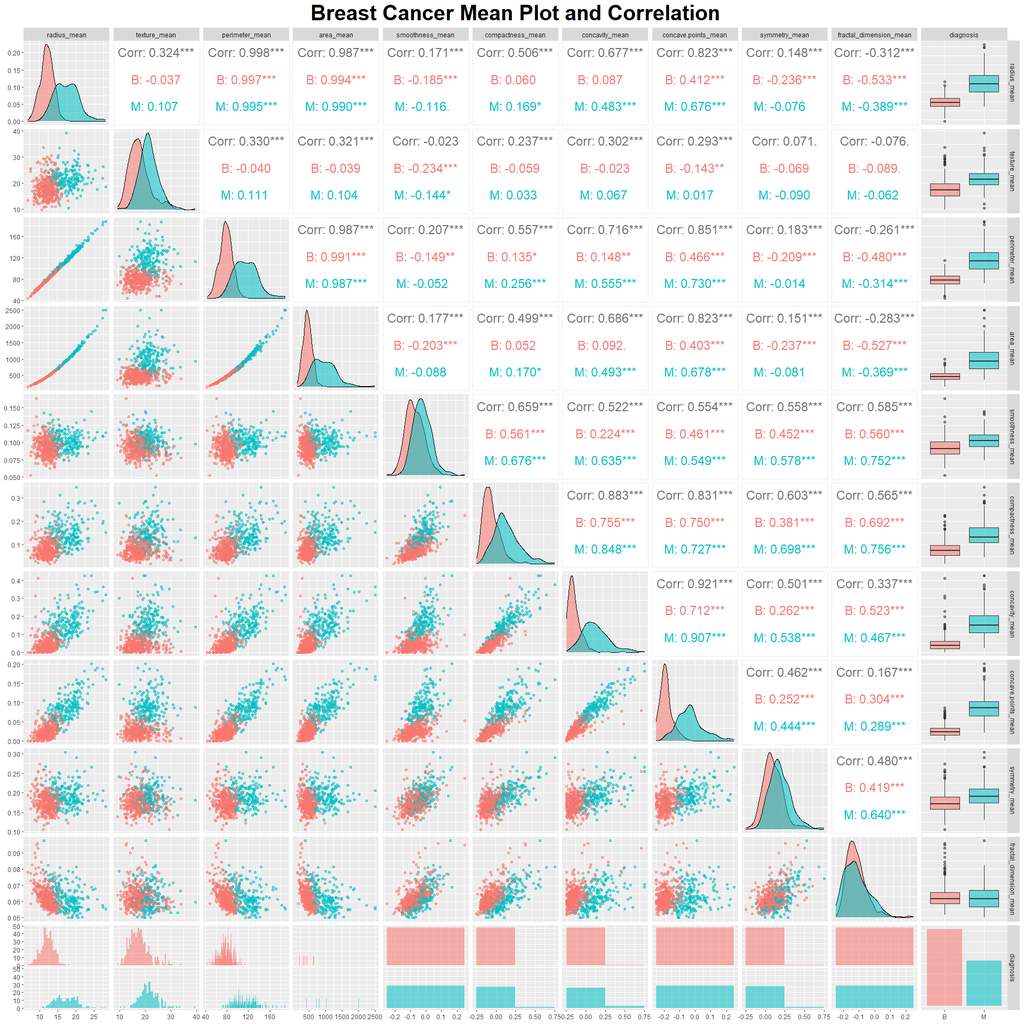

```r
ggpairs(breast_cancer_data[,c(2:11, 1)],
        aes(color=diagnosis, alpha=0.3),
        lower=list(combo=wrap("facethist", binwidth=0.5)),
        upper=list(continuous = wrap("cor", size=6))) +
  labs(title="Breast Cancer Mean Plot and Correlation") +
  theme(plot.title=element_text(face="bold", color="black", hjust=0.5, size=30))
```

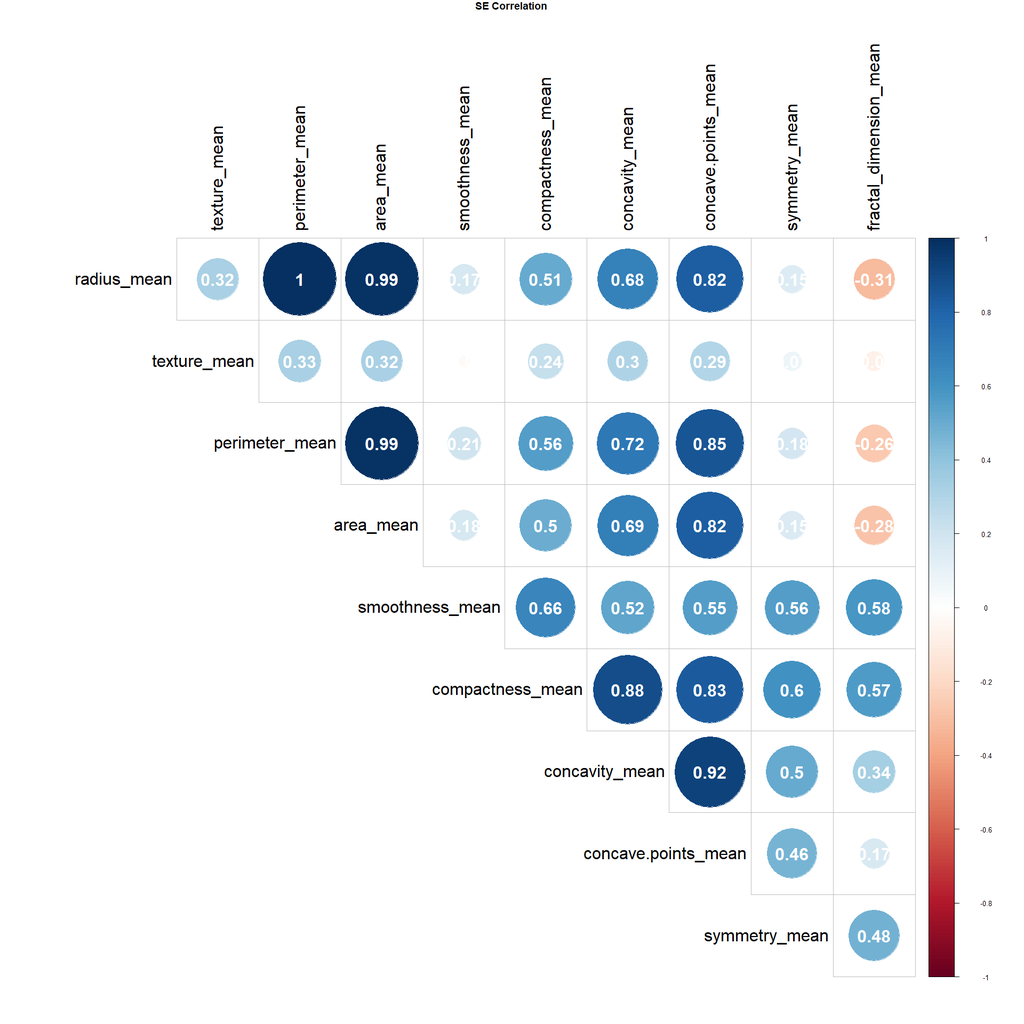

```r
# 간단하게 보기
corrplot(cor(breast_cancer_data[,c(2:11)]),
         type ="upper",
         order = "original",
         tl.col = "black",
         addCoef.col = "white",
         number.cex = 2,
         tl.cex = 2,
         title = "SE Correlation",
         diag=F,
         mar=c(0,0,1,0))
```

- 높은 상관성을 보이는 변수($\rho >0.8$)
  - radius - perimeter: 0.998
  - radius - area: 0.987
  - radius - concave.points: 0.823
  - perimeter - area: 0.987
  - perimeter - concave.points: 0.851
  - area - concave.points: 0.823
  - compactness - concavity: 0.883
  - compactness - concave.points: 0.831
  - concavity - concave.points: 0.921

### 3-2. 표준오차 변수에서의 상관성.

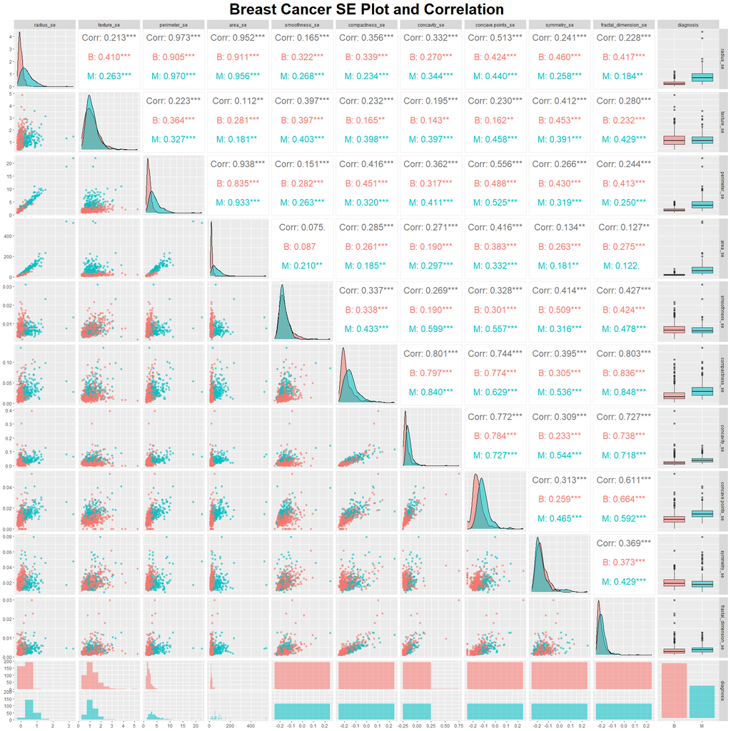

```r
ggpairs(breast_cancer_data[,c(12:21, 1)],
        aes(color=diagnosis, alpha=0.3),
        lower=list(combo=wrap("facethist", binwidth=0.5)),
        upper=list(continuous = wrap("cor", size=6))) +
  labs(title="Breast Cancer SE Plot and Correlation") +
  theme(plot.title=element_text(face="bold", color="black", hjust=0.5, size=30))
```

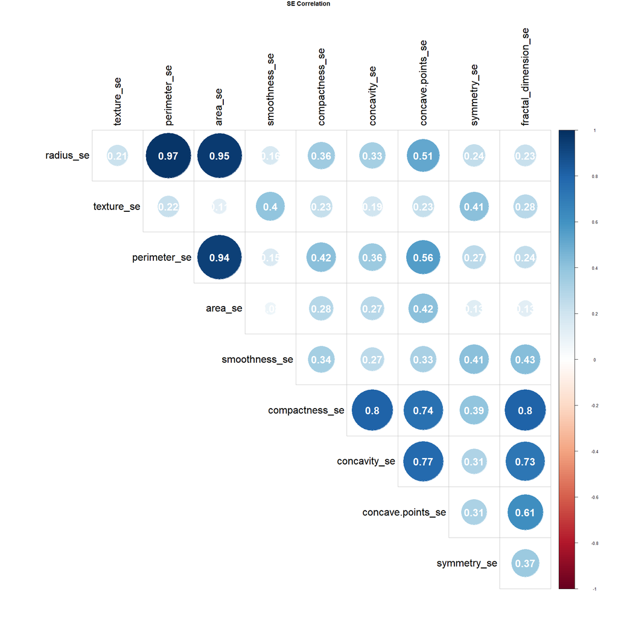

```r
# 간단하게 보기
corrplot(cor(breast_cancer_data[,c(12:21)]),
         type ="upper",
         order = "original",
         tl.col = "black",
         addCoef.col = "white",
         number.cex = 2,
         tl.cex = 2,
         title = "SE Correlation",
         diag=F,
         mar=c(0,0,1,0))
```

- 높은 상관성을 보이는 변수($\rho >0.8$)
  - radius - perimeter: 0.973
  - radius - area : 0.952
  - perimeter - area: 0.938
  - compactness - concavity: 0.801
  - compactness - fractal_dimension: 0.803

### 3-3. Worst 변수에서의 상관성.

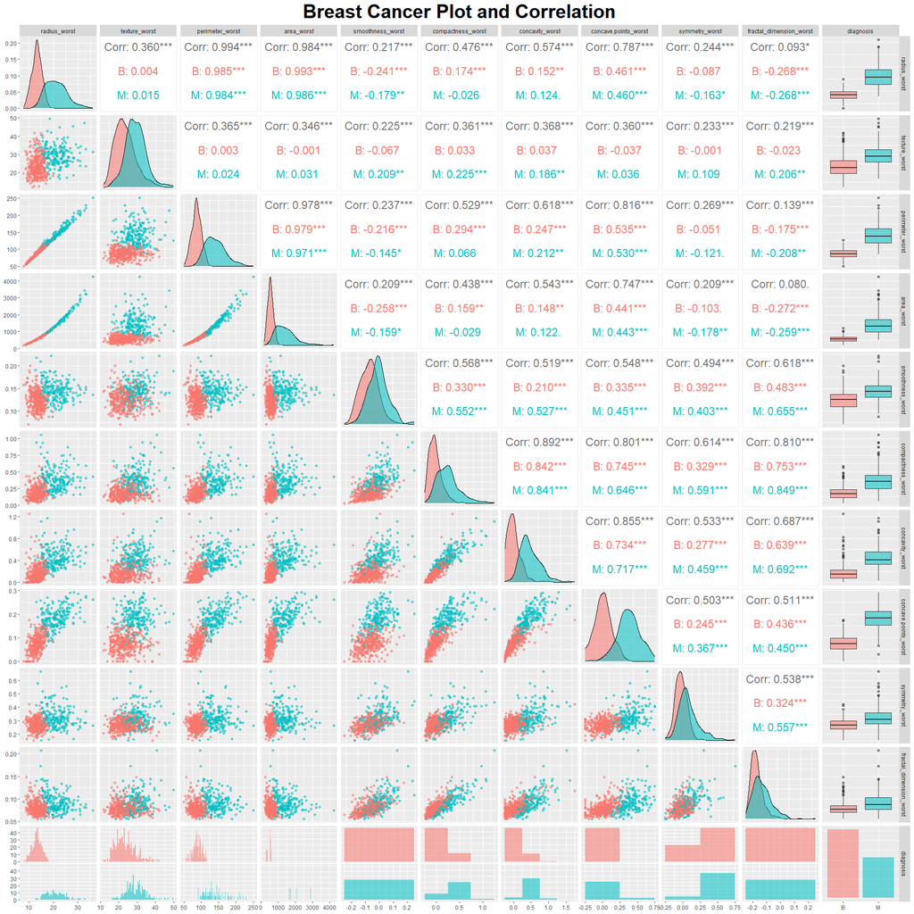

```r
ggpairs(breast_cancer_data[,c(22:31, 1)],
        aes(color=diagnosis, alpha=0.3),
        lower=list(combo=wrap("facethist", binwidth=0.5)),
        upper=list(continuous = wrap("cor", size=6))) +
  labs(title="Breast Cancer Plot and Correlation") +
  theme(plot.title=element_text(face="bold", color="black", hjust=0.5, size=30))
```

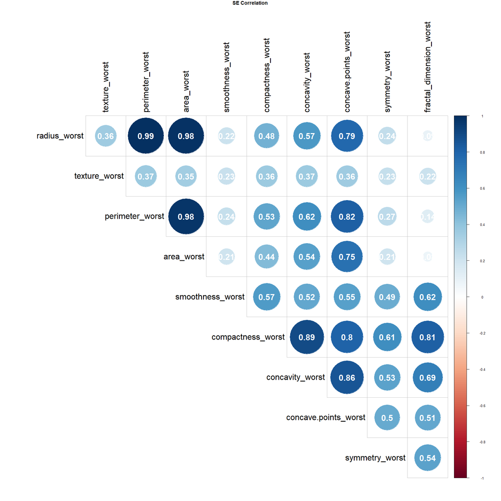

```r
# 간단하게 보기
corrplot(cor(breast_cancer_data[,c(22:31)]),
         type ="upper",
         order = "original",
         tl.col = "black",
         addCoef.col = "white",
         number.cex = 2,
         tl.cex = 2,
         title = "SE Correlation",
         diag=F,
         mar=c(0,0,1,0))
```

- 높은 상관성을 보이는 변수($\rho >0.8$)
  - radius - perimeter: 0.994
  - radius - area: 0.984
  - perimeter - area: 0.978
  - perimeter - concave.points: 0.816
  - compactness - concavity: 0.892
  - compactness - concave.points: 0.801
  - compactness - fractal_dimension: 0.810
  - concavity - concave.points: 0.855

### 3-4. 전체 변수에 대한 상관성.

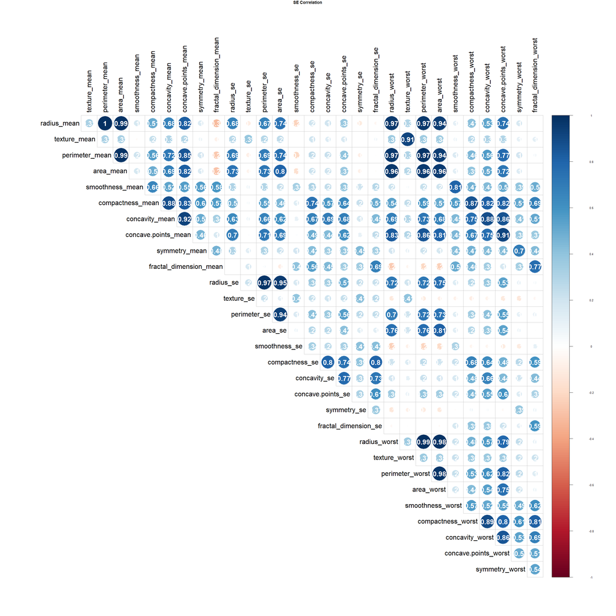

```r
# 간단하게 보기
corrplot(cor(breast_cancer_data[,c(2:31)]),
         type ="upper",
         order = "original",
         tl.col = "black",
         addCoef.col = "white",
         number.cex = 2,
         tl.cex = 2,
         title = "SE Correlation",
         diag=F,
         mar=c(0,0,1,0))
```

> (radius perimeter area) 간의 상관성은 매우 높게 나옵니다. 3가지 변수 모두 크기에 관련된 변수라 그런것이라 생각됩니다. (compactness concavity concave.points) 간의 상관성 또한 높게 나옵니다.